# Spatial Predictive Analysis

Modeling Vacant and Abandoned Property Risk in Chicago

Author

Mohamad AlAbbas

Published

March 31, 2026

## Setup

```r
# Load required packages
library(tidyverse)
library(sf)
library(here)
library(viridis)
library(terra)
library(spdep)
library(FNN)
library(MASS)
library(patchwork)
library(knitr)
library(kableExtra)
library(classInt)
library(readr)
library(dplyr)
library(lubridate)
library(scales)
library(ggfx)
library(units)
library(tidycensus)
library(tidyverse)
library(spatstat)
library(spatstat.geom)
library(spatstat.explore)
library(raster)

# Set options
options(scipen = 999)  # No scientific notation
set.seed(5080)         # Reproducibility

# ── Visual Themes ─────────────────────────────────────────────────────────────
plotTheme <- theme(
  plot.title       = element_text(size = 14, face = "bold"),
  plot.subtitle    = element_text(size = 11, color = "grey40"),
  plot.caption     = element_text(size = 8,  color = "grey55", hjust = 1),
  axis.text        = element_text(size = 9),
  axis.title       = element_text(size = 10, face = "bold"),
  panel.grid.minor = element_blank(),
  panel.background = element_rect(fill = "#fafafa", color = NA),
  plot.background  = element_rect(fill = "white",   color = NA),
  legend.title     = element_text(size = 9,  face = "bold"),
  legend.text      = element_text(size = 8)
)

mapTheme <- theme_void() +
  theme(
    plot.title      = element_text(size = 14, face = "bold"),
    plot.subtitle   = element_text(size = 11, color = "grey40"),
    plot.caption    = element_text(size = 8,  color = "grey55", hjust = 1),
    legend.title    = element_text(size = 9,  face = "bold"),
    legend.text     = element_text(size = 8),
    plot.background = element_rect(fill = "white", color = NA)
  )

palette5 <- c("#f0f9e8", "#bae4bc", "#7bccc4", "#43a2ca", "#0868ac")
```

# 311 Violation Type - Abandoned/Vacant Houses

The violation type I analyze is vacant/abandoned houses. Unlike abandoned cars, which can be towed and moved, vacant houses are fixed and often persist for years. That persistence implies two things: (1) counts and hotspots of vacancy are likely stable over a one-year window, and (2) vacancy may be strongly associated with burglary risk, because prolonged emptiness weakens guardianship and natural surveillance around the property.

For modeling, this slow-moving signal should yield high spatial and temporal autocorrelation, making vacancy a strong predictor of year-to-year burglary variation at the grid-cell level. Still, correlation isn’t causation: shared structural conditions (poverty, tenure, disinvestment) can drive both vacancy and burglary. We address this with controls (income, renter share, poverty, age composition), but some confounding may remain. Finally, 311 reports likely undercount vacancy in high-need areas, so we treat them as a conservative proxy. Given the stability of vacancy, we expect spatial cross-validation to look stronger than pure out-of-time (2018) validation—precisely what our LOGO vs. temporal checks assess.

## Load Data & Boundaries

This chunk loads and prepares all spatial inputs for the analysis: it reads the vacant and abandoned houses CSV, parses the service request date, filters records with valid coordinates from 2017, converts them to an sf point layer in WGS84 and reprojects to ESRI:102271; it reads the burglaries shapefile and reprojects to the same CRS; it downloads police districts and police beats from the Chicago open data portal, reprojects them, and keeps their key ID fields; it loads the Chicago city boundary from GitHub and reprojects it.

```r
# Load abandoned houses
abandoned_houses <- read_csv(here::here("data/Vacant_and_Abandoned_Buildings.csv"), show_col_types = FALSE) %>%
  mutate(date_received = mdy(`DATE SERVICE REQUEST WAS RECEIVED`)) %>%
  filter(!is.na(Latitude), !is.na(Longitude), year(date_received) == 2017) %>%
  st_as_sf(coords = c("Longitude", "Latitude"), crs = 4326) %>%
  st_transform('ESRI:102271')

# Load from provided data file (downloaded from Chicago open data portal)
burglaries <- st_read(here("data", "burglaries.shp")) %>%
  st_transform('ESRI:102271')

# Load police districts (used for spatial cross-validation)
policeDistricts <-
  st_read("https://data.cityofchicago.org/api/geospatial/24zt-jpfn?method=export&format=GeoJSON",
          quiet = TRUE) %>%
  st_transform('ESRI:102271') %>%
  dplyr::select(District = dist_num)

# Load police beats (smaller administrative units)
policeBeats <-
  st_read("https://data.cityofchicago.org/api/geospatial/n9it-hstw?method=export&format=GeoJSON",
          quiet = TRUE) %>%
  st_transform('ESRI:102271') %>%
  dplyr::select(Beat = beat_num)

# Load Chicago boundary
chicagoBoundary <-
  st_read("https://raw.githubusercontent.com/urbanSpatial/Public-Policy-Analytics-Landing/master/DATA/Chapter5/chicagoBoundary.geojson",
          quiet = TRUE) %>%
  st_transform('ESRI:102271')
```

## Visual Distribution of Vacant and Abandoned Houses

This chunk creates two complementary maps to explore vacant and abandoned house locations in 2017: a point map that plots every record on top of the Chicago boundary, and a filled kernel density surface that highlights areas with higher concentrations of points; both layers use the same CRS and styling for consistency, then the two plots are combined side by side with a shared annotation. Note that the combined plot title currently says “Spatial Distribution of Burglaries in Chicago,” which does not match the data being mapped; change it to “Spatial Distribution of Vacant and Abandoned Houses in Chicago” if you want the caption to reflect the content.

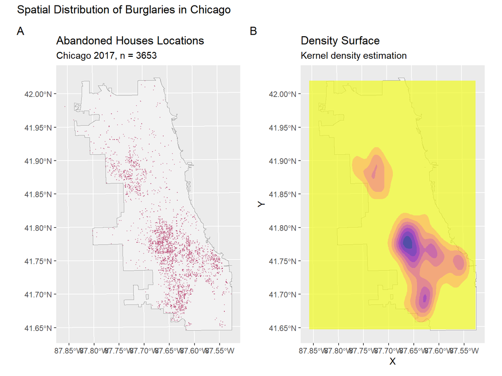

```r
# Simple point map
p1 <- ggplot() +
  geom_sf(data = chicagoBoundary, fill = "gray95", color = "gray60") +
  geom_sf(data = abandoned_houses, color = "maroon", size = 0.2, alpha = 0.4) +
  labs(
    title = "Abandoned Houses Locations",
    subtitle = paste0("Chicago 2017, n = ", nrow(abandoned_houses))
  )

# Density surface using modern syntax
p2 <- ggplot() +
  geom_sf(data = chicagoBoundary, fill = "gray95", color = "gray60") +
  geom_density_2d_filled(
    data = data.frame(st_coordinates(abandoned_houses)),
    aes(X, Y),
    alpha = 0.7,
    bins = 8
  ) +
  scale_fill_viridis_d(
    option = "plasma",
    direction = -1,
    guide = "none"  # Modern ggplot2 syntax (not guide = FALSE)
  ) +
  labs(
    title = "Density Surface",
    subtitle = "Kernel density estimation"
  )

# Combine plots using patchwork (modern approach)
p1 + p2 +
  plot_annotation(
    title = "Spatial Distribution of Burglaries in Chicago",
    tag_levels = 'A'
  )
```

# Fishnet Grid and Vacancy Distribution

This section constructs a regular analysis grid for Chicago, aggregates both vacant or abandoned house reports and burglary incidents to that grid, and then maps the resulting counts so we can inspect how vacancy is distributed across space before modeling.

## Fishnet Creation

The code builds a citywide grid of 500 by 500 meter cells, assigns each cell a unique identifier, clips the grid to the Chicago boundary so only in-city cells remain, and prints a small summary table with the number of cells, the fixed cell size, and the area of a representative cell; this verifies that the grid is correctly sized and spatially aligned before any event aggregation.

```r
# Create 500m x 500m grid
fishnet <- st_make_grid(
  chicagoBoundary,
  cellsize = 500,  # 500 meters per cell
  square = TRUE
) %>%
  st_sf() %>%
  mutate(uniqueID = row_number())

# Keep only cells that intersect Chicago
fishnet <- fishnet[chicagoBoundary, ]

# View basic info
info_tbl <- tibble::tibble(
  Metric = c("Number of cells", "Cell size", "Cell area (m²)"),
  Value  = c(
    scales::comma(nrow(fishnet)),
    "500 × 500 m",
    scales::comma(round(as.numeric(units::drop_units(sf::st_area(fishnet[1, ])))))
  )
)

knitr::kable(
  info_tbl,
  caption   = "Fishnet Summary",
  col.names = c("Metric", "Value"),
  align     = c("l","r"),
  booktabs  = TRUE
) |>
  kableExtra::kable_styling(full_width = FALSE, position = "left",
                            bootstrap_options = c("striped","hover","condensed")) |>
  kableExtra::column_spec(1, bold = TRUE)
```

Fishnet Summary

| Metric | Value |
| --- | --- |
| Number of cells | 2,458 |
| Cell size | 500 × 500 m |
| Cell area (m²) | 250,000 |

## Aggregate Violations Per Grid Cell

The code spatially joins burglary points and vacant or abandoned house points to the grid cells that contain them, computes per-cell counts for each dataset, and attaches those counts back to the grid; cells with no points are set to zero so the counts are usable in models and maps, and a brief summary of the vacancy counts is printed to confirm the distribution after aggregation.

```r
# Spatial join: which cell contains each burglary?
# Aggregate BURGLARIES to the 500m grid
burg_fishnet <- st_join(burglaries, fishnet, join = st_within) %>%
  st_drop_geometry() %>%
  group_by(uniqueID) %>%
  summarize(burglaries = n(), .groups = "drop")

# Spatial join: which cell contains each abandoned/vacant house?
# Aggregate abandoned/vacant house to the 500m grid

houses_fishnet <- st_join(abandoned_houses, fishnet, join = st_within) %>%
  st_drop_geometry() %>%
  group_by(uniqueID) %>%
  summarize(abandoned_houses = n())

# Join back to fishnet (cells with 0 burglaries will be NA)
fishnet <- fishnet %>%
  left_join(burg_fishnet, by = "uniqueID") %>%
  mutate(burglaries = tidyr::replace_na(burglaries, 0))

# Join back to fishnet (cells with 0 abandoned/vacant house will be NA)
fishnet <- fishnet %>%
  left_join(houses_fishnet, by = "uniqueID") %>%
  mutate(abandoned_houses = replace_na(abandoned_houses, 0))

# Basic summary stats
abandoned_summary <- summary(fishnet$abandoned_houses)

# Zero-count cells
zero_count <- sum(fishnet$abandoned_houses == 0)
zero_pct   <- 100 * zero_count / nrow(fishnet)

# Order of numeric stats as in summary()
stat_names <- c("Min.", "1st Qu.", "Median", "Mean", "3rd Qu.", "Max.")

# Extract, round, and format to 2 decimal places
numeric_vals <- abandoned_summary[stat_names]
numeric_vals <- as.numeric(numeric_vals)
numeric_vals <- round(numeric_vals, 2)
numeric_vals <- sprintf("%.2f", numeric_vals)

summary_tbl <- tibble::tibble(
  Statistic = c(
    "Min",
    "1st Quartile",
    "Median",
    "Mean",
    "3rd Quartile",
    "Max",
    "Cells with zero abandoned houses"
  ),
  Value = c(
    numeric_vals,
    paste0(
      scales::comma(zero_count), " / ",
      scales::comma(nrow(fishnet)),
      " (", round(zero_pct, 1), "%)"
    )
  )
)

knitr::kable(
  summary_tbl,
  caption   = "Summary of Vacant/Abandoned House Counts per Grid Cell",
  col.names = c("Statistic", "Value"),
  align     = c("l","r"),
  booktabs  = TRUE
) |>
  kableExtra::kable_styling(
    full_width = FALSE,
    bootstrap_options = c("striped","hover","condensed")
  )
```

Summary of Vacant/Abandoned House Counts per Grid Cell

| Statistic | Value |
| --- | --- |
| Min | 0.00 |
| 1st Quartile | 0.00 |
| Median | 0.00 |
| Mean | 1.49 |
| 3rd Quartile | 1.00 |
| Max | 24.00 |
| Cells with zero abandoned houses | 1,584 / 2,458 (64.4%) |

## Visuals of Count Distribution

The code draws a choropleth of the grid where each cell is filled by its count of vacant or abandoned houses, overlays the city boundary for context, and applies a square-root color transformation with sensible breaks to make skewed count data easier to read; the map title and subtitle document the metric and the 2017 study window.

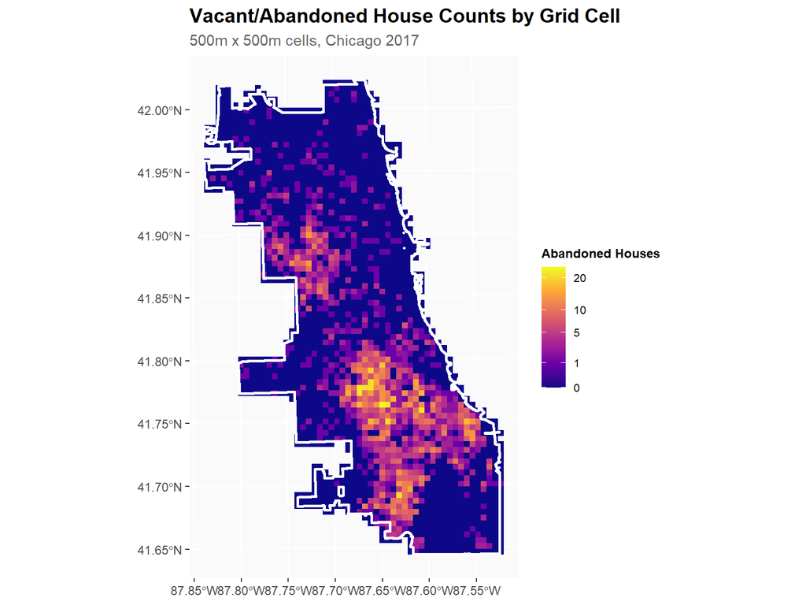

```r
# Visualize aggregated counts
ggplot() +
  geom_sf(data = fishnet, aes(fill = abandoned_houses), color = NA) +
  geom_sf(data = chicagoBoundary, fill = NA, color = "white", linewidth = 1) +
  scale_fill_viridis_c(
    name = "Abandoned Houses",
    option = "plasma",
    trans = "sqrt",  # Square root for better visualization of skewed data
    breaks = c(0, 1, 5, 10, 20, 40)
  ) +
  labs(
    title = "Vacant/Abandoned House Counts by Grid Cell",
    subtitle = "500m x 500m cells, Chicago 2017"
  ) +
  plotTheme
```

# Spatial Features

This section engineers spatial predictors from the vacancy surface and adds contextual controls. It measures proximity to vacant structures, detects statistically significant clusters, converts those clusters into a distance-to-hotspot feature, and enriches the grid with police districts and ACS demographics for use in modeling burglary counts.

## Calculate K-Nearest Neighbor Features

```r
# Get coordinates
fishnet_coords <- st_coordinates(st_centroid(fishnet))
abandoned_coords <- st_coordinates(abandoned_houses)

# Calculate k nearest neighbors and distances
nn_result <- get.knnx(abandoned_coords, fishnet_coords, k = 3)

# Add to fishnet
fishnet <- fishnet %>%
  mutate(
    abandoned_houses.nn = rowMeans(nn_result$nn.dist)
  )

# Summary of mean distance to 3 nearest abandoned houses
nn_summary <- summary(fishnet$abandoned_houses.nn)

# Order of numeric stats as in summary()
stat_names <- c("Min.", "1st Qu.", "Median", "Mean", "3rd Qu.", "Max.")

# Extract, round, and format to 2 decimal places
nn_vals <- nn_summary[stat_names]
nn_vals <- as.numeric(nn_vals)
nn_vals <- round(nn_vals, 2)
nn_vals <- sprintf("%.2f", nn_vals)

nn_tbl <- tibble::tibble(
  Statistic = c("Min", "1st Quartile", "Median", "Mean", "3rd Quartile", "Max"),
  `Distance (m)` = nn_vals
)

knitr::kable(
  nn_tbl,
  caption   = "Summary of Mean Distance to 3 Nearest Vacant/Abandoned Houses (meters)",
  col.names = c("Statistic", "Distance (m)"),
  align     = c("l","r"),
  booktabs  = TRUE
) |>
  kableExtra::kable_styling(
    full_width = FALSE,
    bootstrap_options = c("striped","hover","condensed")
  )
```

Summary of Mean Distance to 3 Nearest Vacant/Abandoned Houses (meters)

| Statistic | Distance (m) |
| --- | --- |
| Min | 3.62 |
| 1st Quartile | 290.58 |
| Median | 613.94 |
| Mean | 786.06 |
| 3rd Quartile | 1068.96 |
| Max | 4773.33 |

## Perform Local Moran’s I analysis

The code creates a k-nearest neighbor weights matrix on grid centroids (k = 5), runs Local Moran’s I on the abandoned_houses counts, and generates a categorical label (High-High, Low-Low, High-Low, Low-High, or Not Significant). This identifies locations where there are hotspots, coldspots, or outliers. This is useful in substantivbe interpretations to discover whether vacnact or abandoned households are in-step or spatially clustered with neighboring households. It actually supports our initial theory that house abandonment (foreclosure) is likely to occur in generally similar neighborhoods.

```r
# Function to calculate Local Moran's I
calculate_local_morans <- function(data, variable, k = 5) {

  # Create spatial weights
  coords <- st_coordinates(st_centroid(data))
  neighbors <- knn2nb(knearneigh(coords, k = k))
  weights <- nb2listw(neighbors, style = "W", zero.policy = TRUE)

  # Calculate Local Moran's I
  local_moran <- localmoran(data[[variable]], weights)

  # Classify clusters
  mean_val <- mean(data[[variable]], na.rm = TRUE)

  data %>%
    mutate(
      local_i = local_moran[, 1],
      p_value = local_moran[, 5],
      is_significant = p_value < 0.05,

      moran_class = case_when(
        !is_significant ~ "Not Significant",
        local_i > 0 & .data[[variable]] > mean_val ~ "High-High",
        local_i > 0 & .data[[variable]] <= mean_val ~ "Low-Low",
        local_i < 0 & .data[[variable]] > mean_val ~ "High-Low",
        local_i < 0 & .data[[variable]] <= mean_val ~ "Low-High",
        TRUE ~ "Not Significant"
      )
    )
}

# Apply to abandoned Houses
fishnet <- calculate_local_morans(fishnet, "abandoned_houses", k = 5)
```

## Identify Hot Spots and Cold Spots

The code draws a choropleth of the moran_class categories to show where significant high clusters (Hot/Cold spots) and low clusters of vacancy occur across the city. The legend clarifies class meanings so the map can be used to visually verify cluster structure before modeling.

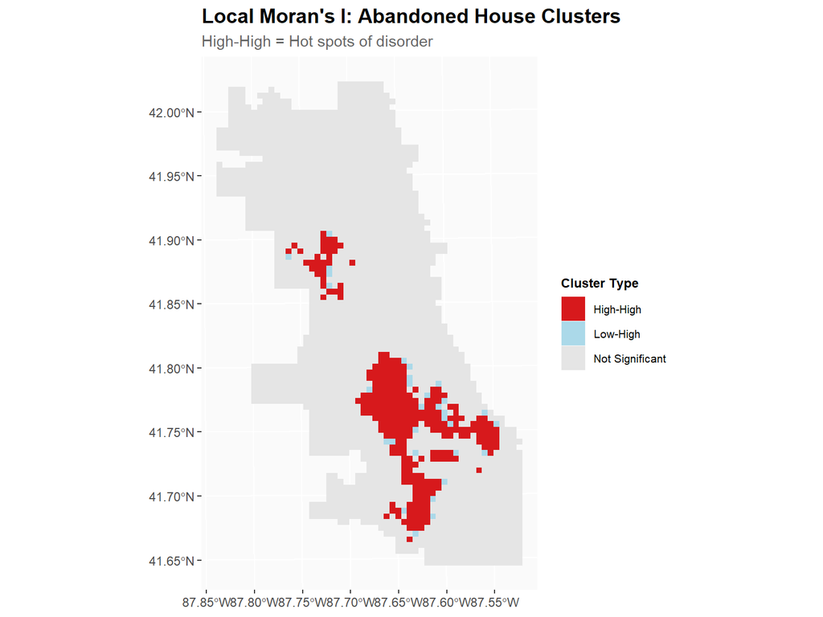

```r
# Visualize hot spots
ggplot() +
  geom_sf(
    data = fishnet,
    aes(fill = moran_class),
    color = NA
  ) +
  scale_fill_manual(
    values = c(
      "High-High" = "#d7191c",
      "High-Low" = "#fdae61",
      "Low-High" = "#abd9e9",
      "Low-Low" = "#2c7bb6",
      "Not Significant" = "gray90"
    ),
    name = "Cluster Type"
  ) +
  labs(
    title = "Local Moran's I: Abandoned House Clusters",
    subtitle = "High-High = Hot spots of disorder"
  ) +
  plotTheme
```

The LISA map shows vacancy hot spots concentrated on the South and Southeast sides, with additional pockets on the Southwest and a few small clusters on the West Side. Most cells are “Not Significant,” which means their vacancy levels are either average or lack strong similarity with neighbors at the k = 5 neighborhood scale. The few “Low-High” cells appear along the fringes of hot areas and indicate local dips embedded within otherwise high-vacancy neighborhoods, consistent with edge effects at cluster boundaries. Overall, the pattern reinforces our earlier findings: vacancy is highly clustered rather than uniform, with multi-cell cores in the south that are likely to be influential in burglary risk modeling and useful for distance-to-hotspot features.

## Create Distance-to-Hotspot Measures

The code extracts centroids of cells labeled High-High, unions them into a single geometry, and computes the distance from each grid centroid to the nearest hotspot. The resulting dist_to_hotspot feature captures how far a location is from the nearest vacancy hot area and defaults to zero when no significant hotspots are found.

```r
# Get centroids of "High-High" cells (hot spots)
hotspots <- fishnet %>%
  filter(moran_class == "High-High") %>%
  st_centroid()

# Calculate distance from each cell to nearest hot spot
if (nrow(hotspots) > 0) {
  fishnet <- fishnet %>%
    mutate(
      dist_to_hotspot = as.numeric(
        st_distance(st_centroid(fishnet), hotspots %>% st_union())
      )
    )
}
```

## Join Additional Contextual Data

The code assigns each grid cell to a police district, then downloads 2017 ACS tract data for Cook County, computes demographic and socioeconomic percentages and median income, and joins these attributes to the grid where cells intersect tracts. These controls (race or ethnicity shares, poverty, renter share, vacancy, age structure, and income) provide broader structural context for explaining burglary patterns beyond vacancy alone.

```r
# Join district information to fishnet
fishnet <- st_join(
  fishnet,
  policeDistricts,
  join = st_within,
  left = TRUE
) %>%
  filter(!is.na(District))  # Remove cells outside districts

cat("✓ Joined police districts\n")
cat("  - Districts:", length(unique(fishnet$District)), "\n")
cat("  - Cells:", nrow(fishnet), "\n")


acs_year <- 2017

# One variable set: race/eth, poverty, tenure, vacancy, income, total pop, and age bins
acs_vars <- c(
  # Totals / Income
  tot_pop = "B03002_001",
  med_inc = "B19013_001",

  # Race / Ethnicity (not Hispanic for white/black; Hispanic any race)
  white   = "B03002_003",
  black   = "B03002_004",
  hisp    = "B03002_012",

  # Poverty
  pov_tot = "B17001_001",
  pov_num = "B17001_002",

  # Tenure & vacancy
  occ_tot = "B25003_001",
  renters = "B25003_003",
  vac_tot = "B25002_001",
  vac_cnt = "B25002_003",

  # --- Age bins from B01001
  # Male 45–64
  m45_49 = "B01001_015",
  m50_54 = "B01001_016",
  m55_59 = "B01001_017",
  m60_61 = "B01001_018",
  m62_64 = "B01001_019",
  # Male 65+
  m65_66 = "B01001_020",
  m67_69 = "B01001_021",
  m70_74 = "B01001_022",
  m75_79 = "B01001_023",
  m80_84 = "B01001_024",
  m85p   = "B01001_025",
  # Female 45–64
  f45_49 = "B01001_039",
  f50_54 = "B01001_040",
  f55_59 = "B01001_041",
  f60_61 = "B01001_042",
  f62_64 = "B01001_043",
  # Female 65+
  f65_66 = "B01001_044",
  f67_69 = "B01001_045",
  f70_74 = "B01001_046",
  f75_79 = "B01001_047",
  f80_84 = "B01001_048",
  f85p   = "B01001_049"
)

# Pull Cook County tracts with geometry
tracts_all <- get_acs(
  geography = "tract",
  state = "IL",
  county = "Cook",
  year = acs_year,
  variables = acs_vars,
  survey = "acs5",
  output = "wide",
  geometry = TRUE
)

# Keep tracts intersecting Chicago boundary; compute metrics
tracts_chi <- tracts_all %>%
  st_transform(st_crs(chicagoBoundary)) %>%
  st_filter(chicagoBoundary, .predicate = st_intersects) %>%
  dplyr::mutate(
    # Age totals
    pop45_64 = (m45_49E + m50_54E + m55_59E + m60_61E + m62_64E +
                f45_49E + f50_54E + f55_59E + f60_61E + f62_64E),
    pop65p   = (m65_66E + m67_69E + m70_74E + m75_79E + m80_84E + m85pE +
                f65_66E + f67_69E + f70_74E + f75_79E + f80_84E + f85pE),

    # Percentages
    pct_white   = 100 * whiteE / pmax(tot_popE, 1),
    pct_black   = 100 * blackE / pmax(tot_popE, 1),
    pct_hisp    = 100 * hispE  / pmax(tot_popE, 1),
    pct_poverty = 100 * pov_numE / pmax(pov_totE, 1),
    pct_renter  = 100 * rentersE / pmax(occ_totE, 1),
    pct_vacant  = 100 * vac_cntE / pmax(vac_totE, 1),
    pct_45_64   = 100 * pop45_64 / pmax(tot_popE, 1),
    pct_65_plus = 100 * pop65p   / pmax(tot_popE, 1),

    med_income  = med_incE
  ) %>%
  dplyr::select(GEOID, pct_white, pct_black, pct_hisp,
                pct_poverty, pct_renter, pct_vacant,
                med_income, pct_45_64, pct_65_plus)

# Join tract attributes to fishnet (centroid/any-intersection)
fishnet <- fishnet %>%
  st_join(tracts_chi, join = st_intersects, left = TRUE)

# (optional) peek
knitr::kable(
  fishnet %>%
    sf::st_drop_geometry() %>%
    dplyr::select(
      abandoned_houses, pct_black, pct_hisp, pct_white,
      pct_poverty, pct_renter, pct_vacant, med_income,
      pct_45_64, pct_65_plus
    ) %>%
    dplyr::slice(1:6),
  caption = "Sample of ACS features joined to fishnet",
  booktabs = TRUE
) %>%
  kableExtra::kable_styling(full_width = FALSE,
                            bootstrap_options = c("condensed","striped"))
```

[output not shown]

# Count Regression Models

This section prepares the modeling frame, fits a Poisson and a Negative Binomial count model for burglaries using vacancy features and ACS controls, checks for overdispersion, and selects the preferred specification based on AIC for downstream prediction and validation.

## Fit Poisson Regression

The code builds fishnet_model by dropping geometry, selecting the outcome burglaries, adding vacancy predictors (abandoned_houses, nearest vacancy distance, distance to vacancy hotspots), and including demographic and socioeconomic controls. Percentage variables are rescaled to proportions and median income is log transformed to reduce skew. A Poisson GLM with log link is then estimated, and a summary is printed to inspect coefficients and standard errors.

```r
fishnet_model <- fishnet %>%
  sf::st_drop_geometry() %>%
  dplyr::select(
    uniqueID,
    District,
    burglaries,
    abandoned_houses,# <-- DV (NEW)
    abandoned_houses.nn,      # keep as a predictor
    dist_to_hotspot,          # keep as a predictor
    pct_black, pct_hisp,
    pct_poverty, pct_renter,
    med_income,
    pct_45_64, pct_65_plus
  ) %>%
  dplyr::mutate(
    across(c(pct_black, pct_hisp, pct_poverty, pct_renter, pct_45_64, pct_65_plus), ~ .x / 100),
    log_income = log(pmax(med_income, 1))
  ) %>%
  tidyr::drop_na()
model_poisson <- glm(
  burglaries ~ abandoned_houses + abandoned_houses.nn + dist_to_hotspot +
    pct_black + pct_hisp + pct_poverty + pct_renter +
    log_income + pct_45_64 + pct_65_plus,
  data   = fishnet_model,
  family = poisson(link = "log")
)

print(summary(model_poisson))
```

```
Call:
glm(formula = burglaries ~ abandoned_houses + abandoned_houses.nn +
    dist_to_hotspot + pct_black + pct_hisp + pct_poverty + pct_renter +
    log_income + pct_45_64 + pct_65_plus, family = poisson(link = "log"),
    data = fishnet_model)

Coefficients:
                        Estimate   Std. Error z value             Pr(>|z|)
(Intercept)         -3.070217563  0.544350632  -5.640 0.000000016990508612 ***
abandoned_houses     0.043922493  0.002161871  20.317 < 0.0000000000000002 ***
abandoned_houses.nn -0.000690608  0.000031488 -21.933 < 0.0000000000000002 ***
dist_to_hotspot     -0.000027902  0.000004719  -5.913 0.000000003356751314 ***
pct_black            0.190029117  0.055329009   3.435             0.000594 ***
pct_hisp             0.046983382  0.056048624   0.838             0.401884
pct_poverty         -1.055645198  0.129211520  -8.170 0.000000000000000309 ***
pct_renter           1.640429873  0.063550330  25.813 < 0.0000000000000002 ***
log_income           0.394106908  0.043623365   9.034 < 0.0000000000000002 ***
pct_45_64            0.013831043  0.173891620   0.080             0.936604
pct_65_plus         -1.472847940  0.191158506  -7.705 0.000000000000013100 ***
---
Signif. codes:  0 '***' 0.001 '**' 0.01 '*' 0.05 '.' 0.1 ' ' 1

(Dispersion parameter for poisson family taken to be 1)

    Null deviance: 15489  on 4203  degrees of freedom
Residual deviance: 11378  on 4193  degrees of freedom
AIC: 22442

Number of Fisher Scoring iterations: 5
```

Burglary counts increase with more vacant houses in a cell and with closer proximity to vacancy. Each additional vacant house is associated with about 4.5% higher expected burglaries (IRR ≈ exp(0.0439) = 1.045). Greater distance to the nearest vacant house lowers risk: a 100 m increase corresponds to ≈ 6.7% lower expected burglaries (IRR ≈ exp(−0.0006906×100) = 0.933). Being farther from vacancy hotspots also reduces risk slightly: 1 km farther gives ≈ 2.7% lower rates (IRR ≈ exp(−0.0000279×1000) = 0.973). Neighborhood structure matters: higher renter share is strongly positive (a 10 percentage-point increase → IRR ≈ exp(0.1×1.640) = 1.18, or +18%), higher log income is positive (IRR ≈ exp(0.394) = 1.48 per one-log increase), and percent Black is positive (10 percentage-points → ~2% higher, IRR ≈ 1.02). Percent Hispanic and ages 45–64 are not significant. Percent in poverty is negative and significant (10 percentage-points → ~10% lower, IRR ≈ exp(−0.1056) = 0.90), likely reflecting overlap with renter share and income. Percent 65+ is negative and significant (10 percentage-points → ~13% lower, IRR ≈ exp(−0.1473) = 0.86).

## Fit Negative Binomial regression

Because Poisson assumes equality of the mean and variance, the code computes a dispersion statistic from the Poisson residuals to diagnose overdispersion. If the statistic is meaningfully above 1.5 the variance exceeds the mean and a Negative Binomial model is more suitable. The same formula is then estimated with glm.nb, which adds a variance parameter to accommodate overdispersion, and its summary is printed.

```r
# Calculate dispersion parameter
dispersion <- sum(residuals(model_poisson, type = "pearson")^2) /
              model_poisson$df.residual

# Build message lines
disp_lines <- c(
  paste0("Dispersion parameter: ", round(dispersion, 2)),
  "Rule of thumb: >1.5 suggests overdispersion",
  if (dispersion > 1.5) {
    "⚠ Overdispersion detected! Consider Negative Binomial model."
  } else {
    "✓ Dispersion looks okay for Poisson model."
  }
)

# Print as a single block
cat(paste(disp_lines, collapse = "\n"))
```

```
Dispersion parameter: 2.8
Rule of thumb: >1.5 suggests overdispersion
⚠ Overdispersion detected! Consider Negative Binomial model.
```

```r
model_nb <- MASS::glm.nb( burglaries ~ abandoned_houses +
                            abandoned_houses.nn +
                            dist_to_hotspot +
                            pct_black + pct_hisp +
                            pct_poverty + pct_renter +
                            log_income +
                            pct_45_64 + pct_65_plus,
                          data = fishnet_model
                          )
summary(model_nb)
```

```
Call:
MASS::glm.nb(formula = burglaries ~ abandoned_houses + abandoned_houses.nn +
    dist_to_hotspot + pct_black + pct_hisp + pct_poverty + pct_renter +
    log_income + pct_45_64 + pct_65_plus, data = fishnet_model,
    init.theta = 2.210092123, link = log)

Coefficients:
                        Estimate   Std. Error z value             Pr(>|z|)
(Intercept)         -3.748657879  0.939928710  -3.988        0.00006656632 ***
abandoned_houses     0.053281881  0.004371109  12.190 < 0.0000000000000002 ***
abandoned_houses.nn -0.000694745  0.000046722 -14.870 < 0.0000000000000002 ***
dist_to_hotspot     -0.000012764  0.000007499  -1.702              0.08875 .
pct_black            0.333974760  0.093409540   3.575              0.00035 ***
pct_hisp             0.198480069  0.094441272   2.102              0.03559 *
pct_poverty         -1.286831447  0.228697285  -5.627        0.00000001836 ***
pct_renter           1.791610947  0.106801787  16.775 < 0.0000000000000002 ***
log_income           0.441167106  0.075452642   5.847        0.00000000501 ***
pct_45_64           -0.079371804  0.296556438  -0.268              0.78897
pct_65_plus         -1.467551579  0.316647262  -4.635        0.00000357529 ***
---
Signif. codes:  0 '***' 0.001 '**' 0.01 '*' 0.05 '.' 0.1 ' ' 1

(Dispersion parameter for Negative Binomial(2.2101) family taken to be 1)

    Null deviance: 6380.7  on 4203  degrees of freedom
Residual deviance: 4836.7  on 4193  degrees of freedom
AIC: 19659

Number of Fisher Scoring iterations: 1

              Theta:  2.2101
          Std. Err.:  0.0854

 2 x log-likelihood:  -19634.6340
```

Overdispersion was substantial (dispersion ≈ 2.79), so moving to a Negative Binomial was appropriate; it fits much better (AIC 19,659; residual deviance 4,837 on 4,193 df) and estimates an overdispersion parameter θ ≈ 2.21. Vacancy intensity and proximity both raise burglary risk; tenure structure (more renters) is a strong correlate; older population share is associated with lower risk. The Negative Binomial specification handles variance better than Poisson and is the recommended model for inference and prediction.

## Compare Model Fit (AIC)

The code compares Poisson and Negative Binomial models using AIC, where lower values indicate a better balance of fit and parsimony. It assigns chosen_model to the model with the smaller AIC, records the winning name, computes the AIC difference, and prints a short recommendation that will guide which model to use for prediction, cross-validation, and temporal tests.

```r
aic_poisson <- AIC(model_poisson)
aic_nb      <- AIC(model_nb)

if (aic_nb < aic_poisson) {
  chosen_model <- model_nb
  chosen_name  <- "Negative Binomial"
  delta        <- aic_poisson - aic_nb
} else {
  chosen_model <- model_poisson
  chosen_name  <- "Poisson"
  delta        <- aic_nb - aic_poisson
}

# Build lines of text
output_lines <- c(
  "Model Comparison (lower AIC is better):",
  paste0(" Poisson AIC: ", round(aic_poisson, 1)),
  paste0(" Negative Binomial AIC: ", round(aic_nb, 1)),
  "",
  "Recommendation:",
  paste0(" \u2192 Use the ", chosen_name,
         " model (\u0394 AIC = ", round(delta, 1),
         " vs. the alternative).")
)

# Print as a single block in the document
cat(paste(output_lines, collapse = "\n"))
```

```
Model Comparison (lower AIC is better):
 Poisson AIC: 22442.2
 Negative Binomial AIC: 19658.6

Recommendation:
 → Use the Negative Binomial model (Δ AIC = 2783.6 vs. the alternative).
```

# Spatial Cross-Validation (2017)

This section evaluates out-of-sample performance with Leave-One-Group-Out cross-validation where each police district is held out in turn. For every fold, the Negative Binomial model is trained on all other districts and then used to predict burglary counts in the held-out district. We then summarize prediction errors to assess how well the model generalizes across space.

## Implement Leave-One-Group-Out cross-validation on 2017 data

The first block loops over districts, splits the data into train and test by district, fits the same NB formula on the training cells, and generates out-of-fold predictions for the held-out district. All predictions are stacked into cv_preds. The second block aggregates these predictions to MAE and RMSE per district, computes overall means (nb_mean_mae, nb_mean_rmse), prints a concise summary, and renders a per-district table for inspection.

```r
# ---- LOGO Cross-Validation (NegBin only; DV = burglaries) ----

districts <- unique(fishnet_model$District)
cv_preds  <- tibble::tibble()

for (i in seq_along(districts)) {
  test_district <- districts[i]

  # Split data
  train_data <- dplyr::filter(fishnet_model, District != test_district)
  test_data  <- dplyr::filter(fishnet_model, District == test_district)

  # Fit Negative Binomial on training fold
  m_nb <- MASS::glm.nb(
    burglaries ~
      abandoned_houses +        # predictor (keep)
      abandoned_houses.nn +     # predictor (keep)
      dist_to_hotspot +         # predictor (keep)
      pct_black + pct_hisp +
      pct_poverty + pct_renter +
      log_income +
      pct_45_64 + pct_65_plus,
    data = train_data
  )

  # Predict on held-out district
  preds <- test_data %>%
    dplyr::transmute(
      fold          = i,
      test_district = test_district,
      uniqueID,
      y             = burglaries,
      pred_negbin   = stats::predict(m_nb, newdata = ., type = "response")
    )

  cv_preds <- dplyr::bind_rows(cv_preds, preds)
}
```

## Calculate and Report Error Metrics (MAE, RMSE)

Lower MAE and RMSE indicate better spatial transferability. Look for: (1) the overall means as your headline performance numbers; (2) districts with notably higher errors, which signal where model assumptions or predictors may not capture local structure; and (3) consistency across folds, which suggests stable generalization rather than overfitting to particular districts.

```r
# ---- Calculate & Report Error Metrics (uses `cv_preds`) ----

# Per-district metrics
cv_results <- cv_preds %>%
  dplyr::group_by(fold, test_district) %>%
  dplyr::summarise(
    n_test      = dplyr::n(),
    mae_negbin  = mean(abs(y - pred_negbin)),
    rmse_negbin = sqrt(mean((y - pred_negbin)^2)),
    .groups = "drop"
  )

# Overall means
nb_mean_mae  <- mean(cv_results$mae_negbin)
nb_mean_rmse <- mean(cv_results$rmse_negbin)

overall_row <- tibble::tibble(
  fold         = NA_integer_,
  test_district= "Overall mean",
  n_test       = sum(cv_results$n_test),
  mae_negbin   = nb_mean_mae,
  rmse_negbin  = nb_mean_rmse
)

cv_table <- dplyr::bind_rows(
  overall_row,
  cv_results %>% dplyr::arrange(dplyr::desc(mae_negbin))
)

knitr::kable(
  cv_table,
  digits  = 3,
  caption = "LOGO CV Results by District and Overall — Negative Binomial (DV = Burglaries)",
  col.names = c("Fold", "District", "N test", "MAE (NB)", "RMSE (NB)"),
  booktabs = TRUE
) %>%
  kableExtra::kable_styling(
    bootstrap_options = c("striped","hover"),
    full_width = FALSE
  )
```

LOGO CV Results by District and Overall — Negative Binomial (DV = Burglaries)

| Fold | District | N test | MAE (NB) | RMSE (NB) |
| --- | --- | --- | --- | --- |
| NA | Overall mean | 4204 | 2.668 | 3.505 |
| 7 | 3 | 120 | 5.680 | 7.192 |
| 6 | 7 | 149 | 3.577 | 4.676 |
| 14 | 11 | 124 | 3.545 | 4.099 |
| 12 | 12 | 203 | 3.202 | 4.337 |
| 8 | 2 | 183 | 3.147 | 3.843 |
| 16 | 25 | 228 | 2.947 | 4.076 |
| 4 | 6 | 154 | 2.893 | 4.052 |
| 17 | 14 | 164 | 2.850 | 4.192 |
| 2 | 4 | 418 | 2.580 | 4.066 |
| 9 | 9 | 291 | 2.570 | 3.048 |
| 5 | 8 | 419 | 2.563 | 3.713 |
| 1 | 5 | 191 | 2.486 | 3.116 |
| 13 | 15 | 77 | 2.380 | 3.093 |
| 18 | 19 | 234 | 2.366 | 3.154 |
| 11 | 1 | 60 | 2.285 | 2.660 |
| 10 | 10 | 173 | 2.254 | 2.857 |
| 15 | 18 | 95 | 2.212 | 3.334 |
| 22 | 24 | 111 | 2.143 | 3.121 |
| 3 | 22 | 229 | 1.921 | 2.366 |
| 21 | 20 | 79 | 1.917 | 2.301 |
| 20 | 17 | 206 | 1.708 | 2.044 |
| 19 | 16 | 296 | 1.463 | 1.777 |

There are a few standout harder to predict districts: District 3 is the clear outlier (MAE 5.68, RMSE 7.19): the model struggles to transfer into this district, likely because its vacancy–burglary relationship or baseline intensity is different from the rest. Districts 7, 11, 12 also post MAE ≈ 3.2–3.6, meaning average errors around three to four incidents per cell. To further understand the problems or causes for these difficult predictions, we’d insepct District 3 (and 7/11/12) for systematic differences: commercial corridors, building stock, guardianship proxies, or reporting patterns.

# KDE-Model Evaluation

## Setting-up KDE

This code block first prepares a kernel density estimate (KDE) of burglary risk and then generates comparable prediction surfaces from both the KDE and the Negative Binomial model. It begins by converting the burglary point data from sf format into a ppp point pattern object (burglaries_ppp) using the Chicago boundary as the observation window. A KDE surface is then computed with a 1 km bandwidth (sigma = 1000), which smooths burglary counts over space while correcting for edge effects. The resultants are converted into a raster, and average KDE values are extracted for each fishnet cell, producing a cell-level variable kde_value that measures historical burglary intensity on the same grid used for modeling.

```r
# Convert burglaries to ppp (point pattern) format for spatstat
burglaries_ppp <- as.ppp(
  st_coordinates(burglaries),
  W = as.owin(st_bbox(chicagoBoundary))
)

# Calculate KDE with 1km bandwidth
kde_burglaries <- density.ppp(
  burglaries_ppp,
  sigma = 1000,  # 1km bandwidth
  edge = TRUE    # Edge correction
)

# Convert to terra raster (modern approach, not raster::raster)
kde_raster <- rast(kde_burglaries)

# Extract KDE values to fishnet cells
fishnet <- fishnet %>%
  mutate(
    kde_value = terra::extract(
      kde_raster,
      vect(fishnet),
      fun = mean,
      na.rm = TRUE
    )[, 2]  # Extract just the values column
  )
```

## KDE Modeling

A final Negative Binomial model is fitted on the training data using the vacancy measures and ACS controls as predictors. Predictions from this model are then mapped back to the spatial grid (the fishnet). The KDE surface is converted into a comparable prediction by rescaling, which yields a predicted KDE, a pseudo-count prediction that sums to the observed total. We then create, three maps of actual burglaries, Negative Binomial predictions, and KDE predictions. The combined figure provides a direct visual comparison between observed counts and the two competing prediction methods.

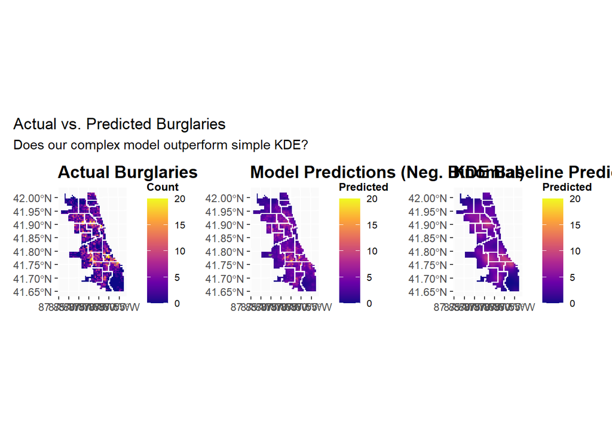

```r
# Fit final model on all data
final_model <- glm.nb(
    burglaries ~  abandoned_houses + abandoned_houses.nn +
      dist_to_hotspot + pct_black + pct_hisp + pct_poverty +
      pct_renter + log_income + pct_45_64 + pct_65_plus,
    data = train_data
  )

# Add predictions back to fishnet
fishnet <- fishnet %>%
  mutate(
    prediction_nb = predict(final_model, fishnet_model, type = "response")[match(uniqueID, fishnet_model$uniqueID)]
  )

# Also add KDE predictions (normalize to same scale as counts)
kde_sum <- sum(fishnet$kde_value, na.rm = TRUE)
count_sum <- sum(fishnet$burglaries, na.rm = TRUE)
fishnet <- fishnet %>%
  mutate(
    prediction_kde = (kde_value / kde_sum) * count_sum
  )

# Create three maps
p1 <- ggplot() +
  geom_sf(data = fishnet, aes(fill = burglaries), color = NA) +
  scale_fill_viridis_c(name = "Count", option = "plasma", limits = c(0, 20)) +
  labs(title = "Actual Burglaries") +
  plotTheme

p2 <- ggplot() +
  geom_sf(data = fishnet, aes(fill = prediction_nb), color = NA) +
  scale_fill_viridis_c(name = "Predicted", option = "plasma", limits = c(0, 20)) +
  labs(title = "Model Predictions (Neg. Binomial)") +
  plotTheme

p3 <- ggplot() +
  geom_sf(data = fishnet, aes(fill = prediction_kde), color = NA) +
  scale_fill_viridis_c(name = "Predicted", option = "plasma", limits = c(0, 20)) +
  labs(title = "KDE Baseline Predictions") +
  plotTheme

p1 + p2 + p3 +
  plot_annotation(
    title = "Actual vs. Predicted Burglaries",
    subtitle = "Does our complex model outperform simple KDE?"
  )
```

The figure above compares observed burglary counts to predictions from the Negative Binomial model and a KDE baseline. The observed map shows clear spatial concentration: burglaries cluster in a broad corridor across the South and Southwest sides and in parts of the West Side, while much of the North and far Northwest record low or zero counts. At the grid-cell level, this pattern is noisy, with sharp spikes in a few cells adjacent to lower-count neighbors, but the overall structure is one of pronounced spatial clustering rather than uniform risk.

The model-based and KDE prediction surfaces both recover this broad pattern but differ in how they represent risk. The Negative Binomial model, which incorporates vacancy measures and ACS neighborhood characteristics, reproduces the main hot corridors while smoothing out cell-level noise, yielding more coherent patches of elevated risk. In contrast, the KDE baseline produces larger, amorphous “blobs” centered on past burglary locations and offers less differentiation within and around these hot areas. Because KDE relies solely on historical burglary intensity, it cannot highlight structurally vulnerable areas with few past incidents, while the model can assign elevated risk to such locations when vacancy and socioeconomic conditions resemble known hot spots. Overall, the visual comparison suggests that the more complex model provides a sharper and more interpretable risk surface than simple KDE smoothing.

## KDE Model Comparison

This block computes summary performance metrics that quantify how closely each prediction surface matches the observed burglary counts.

```r
# Calculate performance metrics
comparison <- fishnet %>%
  st_drop_geometry() %>%
  filter(!is.na(prediction_nb), !is.na(prediction_kde)) %>%
  summarize(
    model_mae = mean(abs(burglaries - prediction_nb)),
    model_rmse = sqrt(mean((burglaries - prediction_nb)^2)),
    kde_mae = mean(abs(burglaries - prediction_kde)),
    kde_rmse = sqrt(mean((burglaries - prediction_kde)^2))
  )

comparison %>%
  pivot_longer(everything(), names_to = "metric", values_to = "value") %>%
  separate(metric, into = c("approach", "metric"), sep = "_") %>%
  pivot_wider(names_from = metric, values_from = value) %>%
  kable(
    digits = 2,
    caption = "Model Performance Comparison"
  ) %>%
  kable_styling(bootstrap_options = c("striped", "hover"))
```

Model Performance Comparison

| approach | mae | rmse |
| --- | --- | --- |
| model | 2.51 | 3.50 |
| kde | 2.17 | 3.06 |

The performance table shows that, when predicting 2017 burglary counts at the grid-cell level, the KDE baseline actually achieves **slightly lower errors** than the vacancy-based model: MAE 2.17 vs. 2.51 and RMSE 3.06 vs. 3.50. In other words, on average the KDE surface is closer to the observed burglary counts, and it makes somewhat fewer large mistakes. This is not surprising given that KDE is essentially a smoothed re-expression of the historical burglary pattern itself; it is designed to fit those data very closely and therefore performs well on this kind of within-year predictive task.

These results temper the earlier, more favorable qualitative impression of the Negative Binomial model. Visually, the model produces a more structured and interpretable risk surface that aligns with vacancy and neighborhood conditions, but that extra structure does not translate into lower error for this particular comparison, if anything, the simple “hotspot from past crimes” approach is modestly more accurate. Substantively, this suggests that for **short-term, same-period prediction**, historical burglary locations remain a very strong predictor and can outperform a more complex model. The added value of the model may lie more in its interpretability and in its potential for **out-of-time generalization** (e.g., to a future year or to emerging hot spots) rather than in raw in-sample predictive accuracy against the 2017 pattern.

## Prediction Errors

This code block examines where each method performs poorly by mapping residuals over space.Two error maps are then created, one for each KDE and Negative Binomial.

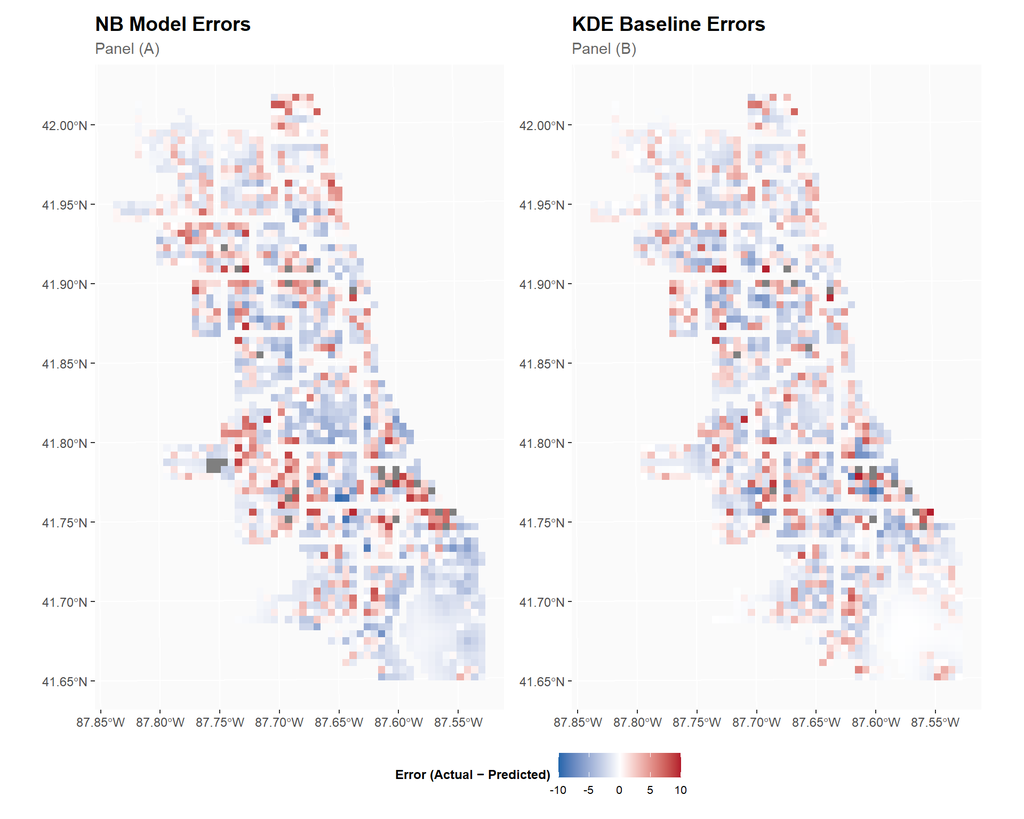

```r
# Calculate errors
fishnet <- fishnet %>%
  mutate(
    error_nb     = burglaries - prediction_nb,
    error_kde    = burglaries - prediction_kde,
    abs_error_nb = abs(error_nb),
    abs_error_kde= abs(error_kde)
  )

# NB model errors
p1 <- ggplot() +
  geom_sf(data = fishnet, aes(fill = error_nb), color = NA) +
  scale_fill_gradient2(
    name     = "Error (Actual − Predicted)",
    low      = "#2166ac",
    mid      = "white",
    high     = "#b2182b",
    midpoint = 0,
    limits   = c(-10, 10)
  ) +
  labs(
    title    = "NB Model Errors",
    subtitle = "Panel (A)"
  ) +
  plotTheme

# KDE errors
p2 <- ggplot() +
  geom_sf(data = fishnet, aes(fill = error_kde), color = NA) +
  scale_fill_gradient2(
    name     = "Error (Actual − Predicted)",
    low      = "#2166ac",
    mid      = "white",
    high     = "#b2182b",
    midpoint = 0,
    limits   = c(-10, 10)
  ) +
  labs(
    title    = "KDE Baseline Errors",
    subtitle = "Panel (B)"
  ) +
  plotTheme

# Combine with shared legend and panel tags
(p1 + p2) +
  plot_layout(guides = "collect") &
  theme(legend.position = "bottom")
```

Panel (A) maps the signed errors for the Negative Binomial model (actual minus predicted burglaries), while Panel (B) does the same for the KDE baseline. In both panels, red cells indicate places where the model **under-predicts** burglaries and blue cells where it **over-predicts**. The mix of red and blue across the city suggests that neither approach has a strong global bias: both overshoot in some neighborhoods and undershoot in others. The largest errors in both maps tend to occur in or near the main burglary corridors on the South, Southwest, and parts of the West Side, which is expected because these are the areas with the highest underlying counts and thus the most room for large discrepancies.

Comparing the two panels, the spatial pattern of errors is broadly similar, but with some subtle differences. The KDE baseline in Panel (B) tends to make larger mistakes right at the cores of historical hot spots, where its smooth kernel surface can either overconcentrate risk or miss micro-level variation along hot-spot edges. The Negative Binomial model in Panel (A) shows a slightly more diffuse pattern of residuals, with errors spread across structurally similar neighborhoods rather than tightly glued to past event locations. This aligns with the numeric evaluation: KDE attains somewhat lower MAE/RMSE overall, but both methods struggle most in the same high-crime corridors. The model’s advantage remains interpretive and structural, tying errors to vacancy and neighborhood context, rather than a clear reduction in spatial prediction error.

# Temporal Validation on 2018 Burglaries

## Load and Aggregate 2018 Burglaries

This block reads the 2018 crimes CSV, filters to burglary records with valid latitude and longitude, converts them to an sf point layer, reprojects to ESRI:102271, then spatially joins points to the existing 500 m grid and aggregates a per-cell count burglaries_2018. The result is a tidy table of 2018 burglary counts keyed by uniqueID.

```r
bulgary2018 <- read_csv(here::here("data/crime2018.csv"), show_col_types = FALSE) %>%
  filter(Year == 2018, !is.na(Latitude), !is.na(Longitude),
         stringr::str_detect(toupper(`Primary Type`), "BURGLARY")) %>%
  st_as_sf(coords = c("Longitude", "Latitude"), crs = 4326) %>%
  st_transform('ESRI:102271')

burg_2018_fishnet <- bulgary2018 %>%
  sf::st_join(fishnet, join = sf::st_within) %>%
  sf::st_drop_geometry() %>%
  dplyr::group_by(uniqueID) %>%
  dplyr::summarise(burglaries_2018 = dplyr::n(), .groups = "drop")
```

## Build Prediction Frame and Compute Temporal Metrics

This block attaches the 2018 counts to a copy of the fishnet (leaving the original intact), fills missing counts with zero, and constructs pred_frame_2018 with the same predictors used in 2017 (vacancy features and ACS controls), applying the same transformations (percent to proportion, log income). It then uses your previously selected chosen_model (Negative Binomial) to generate 2018 predictions, and computes overall MAE and RMSE plus by-district MAE and RMSE to quantify temporal generalization.

```r
# keep your original fishnet intact; attach 2018 counts to a copy
fishnet_2018 <- fishnet %>%
  dplyr::left_join(burg_2018_fishnet, by = "uniqueID") %>%
  dplyr::mutate(burglaries_2018 = dplyr::coalesce(burglaries_2018, 0L))

pred_frame_2018 <- fishnet_2018 %>%
  sf::st_drop_geometry() %>%
  dplyr::transmute(
    uniqueID, District,
    burglaries_2018,                  # 2018 DV for evaluation
    abandoned_houses,
    abandoned_houses.nn,
    dist_to_hotspot,
    pct_black, pct_hisp, pct_poverty, pct_renter,
    med_income,
    pct_45_64, pct_65_plus
  ) %>%
  dplyr::mutate(
    dplyr::across(c(pct_black, pct_hisp, pct_poverty, pct_renter, pct_45_64, pct_65_plus), ~ .x/100),
    log_income = log(pmax(med_income, 1))
  ) %>%
  tidyr::drop_na()

stopifnot(exists("chosen_model"))
pred_frame_2018 <- pred_frame_2018 %>%
  dplyr::mutate(pred_2018_nb = stats::predict(chosen_model, newdata = pred_frame_2018, type = "response"))

temporal_overall <- pred_frame_2018 %>%
  dplyr::summarise(
    mae_nb  = mean(abs(burglaries_2018 - pred_2018_nb)),
    rmse_nb = sqrt(mean((burglaries_2018 - pred_2018_nb)^2))
  )

temporal_by_district <- pred_frame_2018 %>%
  dplyr::group_by(District) %>%
  dplyr::summarise(
    n_cells = dplyr::n(),
    mae_nb  = mean(abs(burglaries_2018 - pred_2018_nb)),
    rmse_nb = sqrt(mean((burglaries_2018 - pred_2018_nb)^2)),
    .groups = "drop"
  )

print(temporal_overall)
```

```
    mae_nb  rmse_nb
1 18.04675 28.20788
```

## Report Results and Compare to Spatial Cross-Validation

This block prints a formatted table of the 2018 errors by district and a compact comparison table that lines up the 2017 spatial LOGO averages against the 2018 temporal metrics, so you can see at a glance whether the model transfers better across space or across time.

```r
temporal_by_district %>%
  dplyr::arrange(dplyr::desc(mae_nb)) %>%
  knitr::kable(
    digits = 3,
    caption = "2018 Temporal Validation by District — NegBin (DV = Burglaries)",
    col.names = c("District", "N cells", "MAE (NB)", "RMSE (NB)"),
    booktabs = TRUE
  ) %>%
  kableExtra::kable_styling(bootstrap_options = c("striped","hover"), full_width = FALSE)
```

2018 Temporal Validation by District — NegBin (DV = Burglaries)

| District | N cells | MAE (NB) | RMSE (NB) |
| --- | --- | --- | --- |
| 3 | 120 | 39.856 | 53.333 |
| 18 | 95 | 38.327 | 54.867 |
| 19 | 234 | 35.483 | 42.912 |
| 14 | 164 | 35.228 | 42.197 |
| 15 | 77 | 28.792 | 38.074 |
| 20 | 79 | 26.445 | 37.655 |
| 6 | 154 | 22.882 | 33.308 |
| 7 | 149 | 22.333 | 29.426 |
| 24 | 111 | 21.488 | 25.800 |
| 12 | 203 | 20.462 | 27.418 |
| 2 | 183 | 19.652 | 26.599 |
| 11 | 124 | 19.589 | 26.619 |
| 10 | 173 | 18.413 | 24.248 |
| 17 | 206 | 17.559 | 29.199 |
| 25 | 228 | 16.741 | 21.907 |
| 9 | 291 | 14.056 | 22.988 |
| 8 | 419 | 12.521 | 19.283 |
| 4 | 418 | 10.188 | 24.262 |
| 1 | 60 | 8.631 | 13.178 |
| 5 | 191 | 7.185 | 10.390 |
| 22 | 229 | 7.116 | 10.560 |
| 16 | 296 | 6.446 | 9.811 |

```r
compare_st <- tibble::tibble(
  validation = c("Spatial LOGO (2017)", "Temporal (2018)"),
  MAE  = c(nb_mean_mae,  temporal_overall$mae_nb),
  RMSE = c(nb_mean_rmse, temporal_overall$rmse_nb)
)

compare_st %>%
  knitr::kable(
    digits = 3,
    caption = "Spatial (2017 LOGO) vs Temporal (2018) — Negative Binomial"
  ) %>%
  kableExtra::kable_styling(bootstrap_options = c("striped","hover"), full_width = FALSE)
```

Spatial (2017 LOGO) vs Temporal (2018) — Negative Binomial

| validation | MAE | RMSE |
| --- | --- | --- |
| Spatial LOGO (2017) | 2.668 | 3.505 |
| Temporal (2018) | 18.047 | 28.208 |

## Map Actuals, Predictions, and Errors

This block builds three choropleths over the grid: actual 2018 burglary counts, the model’s 2018 predictions, and the error surface (actual minus predicted). Shown side by side, these maps help diagnose where the model under- or over-predicts when moved forward one year.

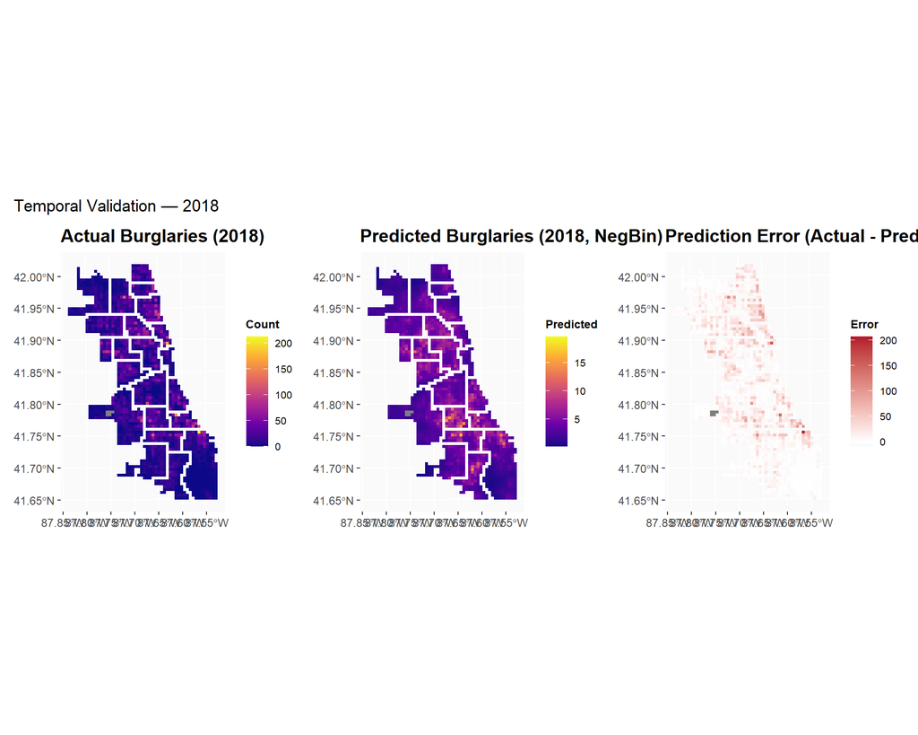

```r
fishnet_2018_map <- fishnet %>%
  dplyr::left_join(pred_frame_2018 %>% dplyr::select(uniqueID, burglaries_2018, pred_2018_nb), by = "uniqueID") %>%
  dplyr::mutate(error_2018_nb = burglaries_2018 - pred_2018_nb)

p_act <- ggplot() +
  geom_sf(data = fishnet_2018_map, aes(fill = burglaries_2018), color = NA) +
  scale_fill_viridis_c(name = "Count", option = "plasma") +
  labs(title = "Actual Burglaries (2018)") + plotTheme

p_pred <- ggplot() +
  geom_sf(data = fishnet_2018_map, aes(fill = pred_2018_nb), color = NA) +
  scale_fill_viridis_c(name = "Predicted", option = "plasma") +
  labs(title = "Predicted Burglaries (2018, NegBin)") + plotTheme

p_err <- ggplot() +
  geom_sf(data = fishnet_2018_map, aes(fill = error_2018_nb), color = NA) +
  scale_fill_gradient2(name = "Error", low = "#2166ac", mid = "white", high = "#b2182b", midpoint = 0) +
  labs(title = "Prediction Error (Actual - Predicted, 2018)") + plotTheme

p_act + p_pred + p_err + patchwork::plot_annotation(title = "Temporal Validation — 2018")
```